# An Introduction To ngsReports

Christopher Ward, Hien To and Steve Pederson

School of Biological Sciences, University of Adelaide  
Bioinformatics Hub, University of Adelaide

stephen.pederson@adelaide.edu.au

26 January 2019

#### Package

ngsReports 0.99.0

# Contents

```r
knitr::opts_chunk$set(message = FALSE, warning = FALSE)
```

# 1 Introduction

The package `ngsReports` is designed to bolt into data processing pipelines and produce combined plots for FastQC reports across an entire set of libraries. Output as generated by the tool [FastQC](https://www.bioinformatics.babraham.ac.uk/projects/fastqc/) will be loaded and replotted using functions from *ggplot2* and *plotly*, as well as custom summary plots. Tables of read counts can also be easily generated.

# 2 Basic Usage

## 2.1 Using the Shiny App

In addition to the useage demonstrated below, a `shiny` app has been developed for interactive viewing of FastQC reports. This can be installed using:

```
remotes::install_github(UofABioinformaticsHub/shinyNgsReports)
```

A vignette for this app will be installed with the package.

## 2.2 The default report

In it’s simplest form, a default report can be generated simply by specifying a directory containing the output from FastQC and calling the function `writeHtmlReport()`.

```r
library(ngsReports)
```

```r
fileDir <- system.file("extdata", package = "ngsReports")
writeHtmlReport(fileDir)
```

This function will transfer the default template to the provided directory and produce a single `.html` file containing interactive summary plots of any FastQC output found in the directory. FastQC output can be `*fastqc.zip` files or the same files extracted as individual directories.

The default template is provided as `ngsReports_Fastqc.Rmd` in the package directory. This can be easily modified and supplied as an alternate template to the above function.

```r
altTemplate <- file.path("path", "to", "template.Rmd")
writeHtmlReport(fileDir, template = altTemplate)
```

# 3 Advanced Usage

## 3.1 Classes Defined in the Package

The package `ngsReports` introduces four basic `S4` classes:

- `FastqcFile` & `FastqcFileList`
- `FastqcData` & `FastqcDataList`

`FastqcFile` and `FastqcData` objects respectively hold the location and information from a single report as generated by the stand-alone tool `FastQC`. These are then extended into lists for more than one file. `FastqcFile` and `FastqcFileList` objects simply contain the path to these reports after checking the files contain the files always output by this tool. `FastqcData` and `FastqcDataList` objects contain the *parsed data* from the reports. For most users, the primary class of interest will be the `FastqcDataList`

https://www.bioinformatics.babraham.ac.uk/projects/fastqc/

## 3.2 Loading FastQC Data Into `R`

To load a set of `FastQC` reports into `R` as a `FastqcDataList`, specify the set of files, then call the function `getFastqcData()`.

```r
fileDir <- system.file("extdata", package = "ngsReports")
files <- list.files(fileDir, pattern = "fastqc.zip$", full.names = TRUE)
fdl <- getFastqcData(files)
```

From here, all FastQC modules can be obtained as a `tibble` (i.e. `data.frame`) using the functions:

- `Basic_Statistics(fdl)`
- `Per_base_sequence_quality(fdl)`
- `Per_sequence_quality_scores(fdl)`
- `Per_base_sequence_content(fdl)`
- `Per_sequence_GC_content(fdl)`
- `Per_base_N_content(fdl)`
- `Sequence_Length_Distribution(fdl)`
- `Sequence_Duplication_Levels(fdl)`
- `Overrepresented_sequences(fdl)`
- `Adapter_Content(fdl)`
- `Kmer_Content(fdl)`
- `Per_tile_sequence_quality(fdl)`

In addition, the read totals for each file in the library can be obtained using, whiich can be easily used to make a table of read totals.

```r
reads <- readTotals(fdl)
```

```r
library(dplyr)
library(pander)
filter(reads, grepl("R1", Filename)) %>%
  pander(big.mark = ",")
```

| Filename | Total_Sequences |
| --- | --- |
| ATTG_R1.fastq | 24,978 |
| CCGC_R1.fastq | 22,269 |
| GACC_R1.fastq | 10,287 |
| TTAT_R1.fastq | 51,496 |

One additional module is available and taken directly from the text within the supplied reports

- `Total_Duplicated_Percentage(fdl)`

## 3.3 Generating Plots

Plots created from a single `FastqcData` object will resemble those generated by the `FastQC` tool, whilst those created from a `FastqcDataList` will be combined summaries across a library of files. All plots are able to be generated as interactive plots using the argument `usePlotly = TRUE`.

Most modules have been enabled for plotting using default `S4` dispatch.

### 3.3.1 plotSummary()

A summary of all `PASS/WARN/FAIL` flags can be simply generated

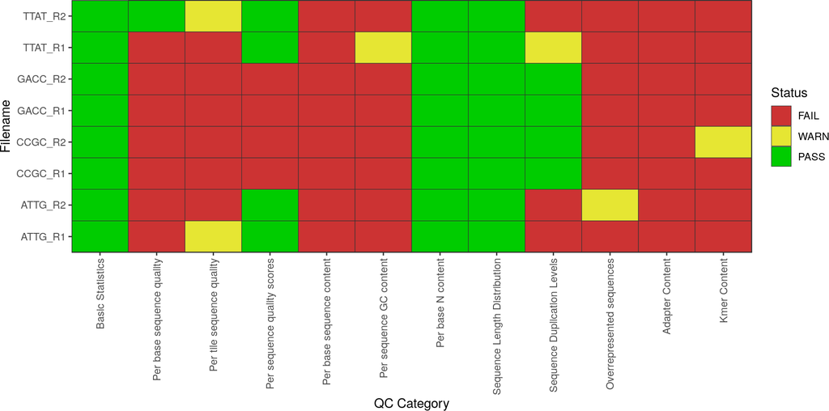

Figure 1: Default summary of FastQC flags

```r
plotSummary(fdl)
```

### 3.3.2 plotReadTotals()

Read totals from all files in the library can be simply plotted. By default, the number of duplicated sequences from the `Total_Duplicated_Percentage` module are shown, but this can be disabled by setting `duplicated = FALSE`.

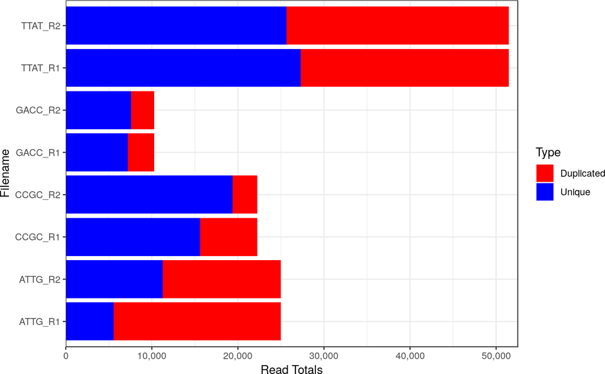

```r
plotReadTotals(fdl)
```

As these are `ggplot2` objects, the output can be modified easily using conventional `ggplot2` syntax.

[figure not shown]

```r
plotReadTotals(fdl) +
  geom_vline(xintercept = 25000, linetype = 2)
```

### 3.3.3 plotBaseQualities()

A heatmap of the entire `Per base sequence quality` scores can by generated, using the mean as representative of the scores at each position. The median can also be selected using `plotValue = "Median"`

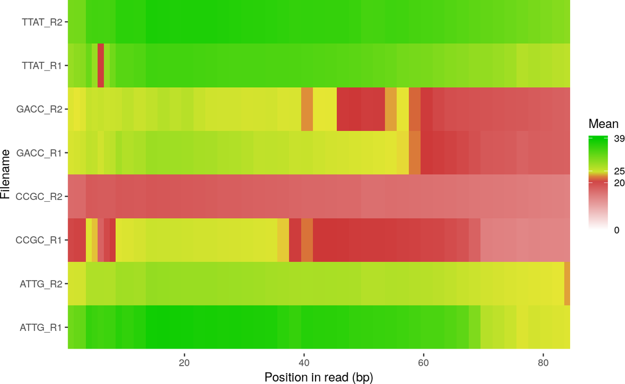

```r
plotBaseQualities(fdl)
```

The conventional boxplot for a single file can be created by specifying a single `FastqcData` or `FastqcFile` object.

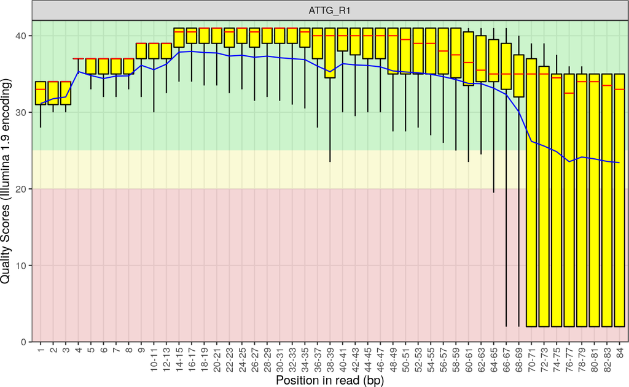

```r
plotBaseQualities(fdl[[1]])
```

Boxplots of any combinations can also be drawn from a `FastqcDataList` or `FastqcFileList` by setting the argument `plotType = "boxplot"`

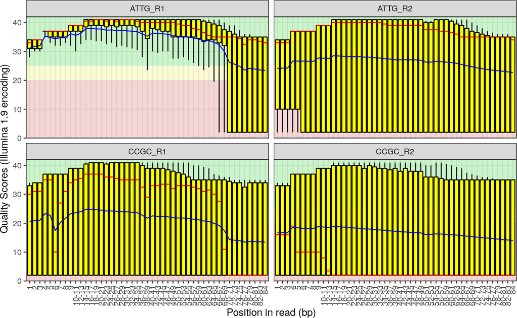

```r
plotBaseQualities(fdl[1:4], plotType = "boxplot")
```

### 3.3.4 plotSequenceQualities()

A heatmap of mean sequence qualities can be generated, with the alternative being a set of overlaid lines.

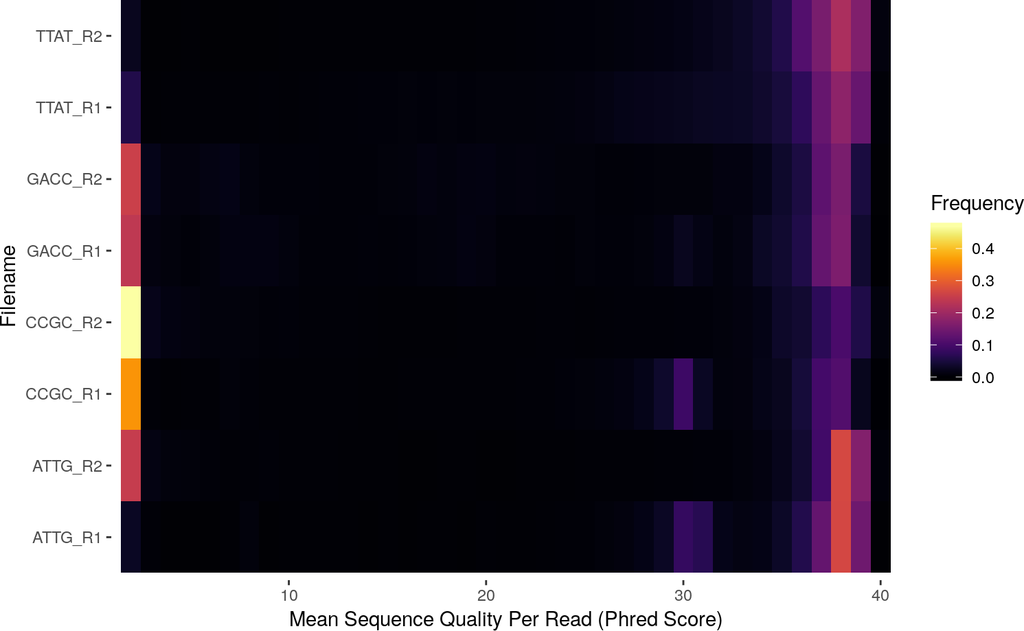

```r
plotSequenceQualities(fdl)
```

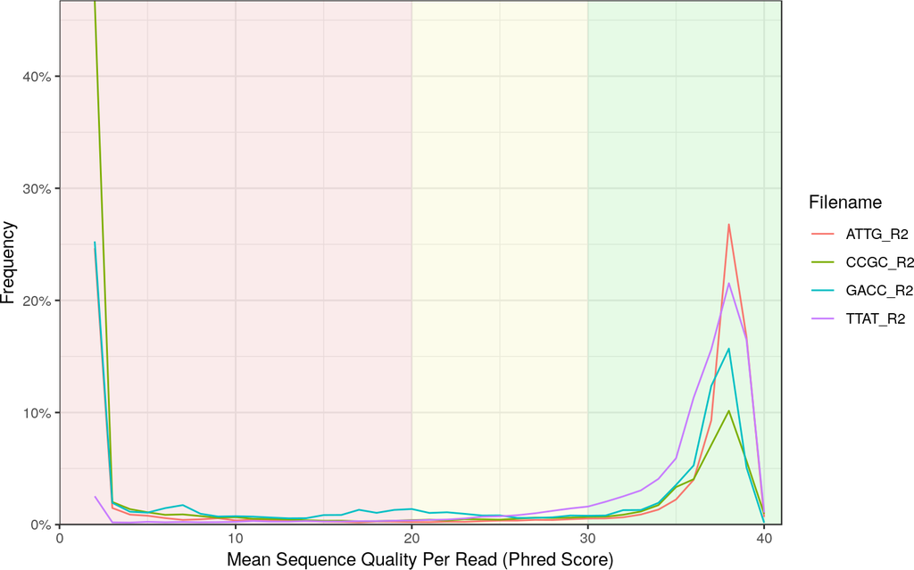

```r
r2 <- grepl("R2", fileName(fdl))
plotSequenceQualities(fdl[r2], plotType = "line")
```

### 3.3.5 plotSequenceContent()

Heatmaps showing a composite colour for each position can be drawn. Colours are combined using `rgb()` with `A`,`C`, `G` and `T` being represented by green, blue, black and red respectively.

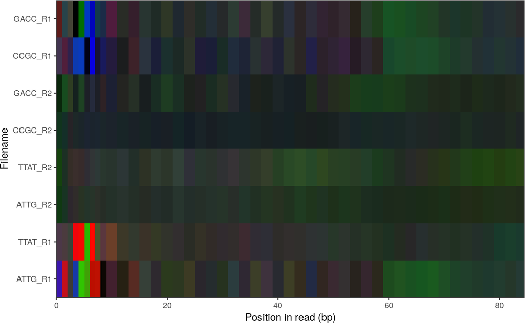

```r
plotSequenceContent(fdl)
```

Individual plots can also be drawn using a `FastqcData` or `FastqcFile` object

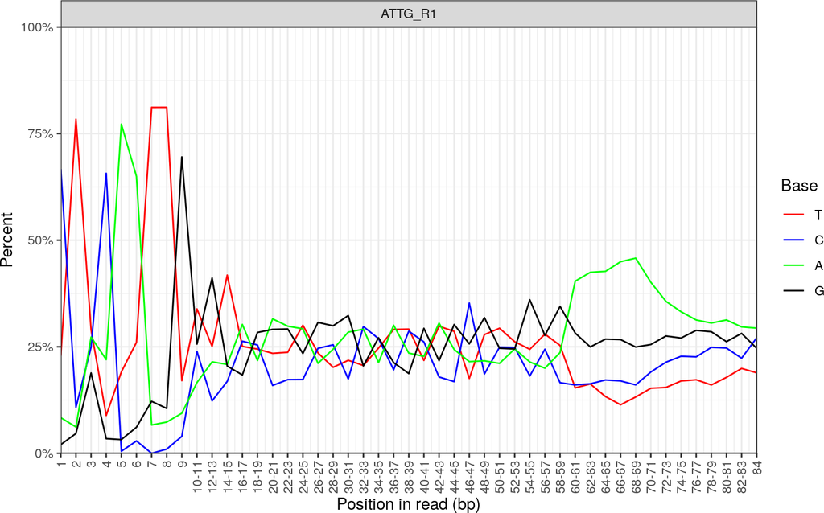

```r
plotSequenceContent(fdl[[1]])
```

### 3.3.6 plotNContent()

N content can also be checked. The example dataset contained no N content, and so a “blank” plot will be produced.

```r
plotNContent(fdl)
```

[output not shown]

### 3.3.7 plotSequenceLengthDistribution

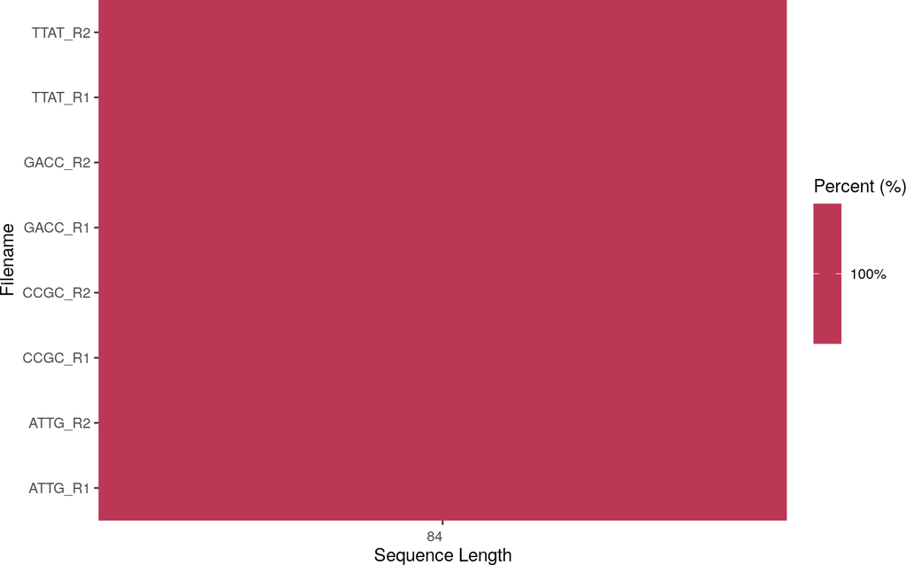

```r
plotSequenceLengthDistribution(fdl)
```

### 3.3.8 plotDuplicationLevels()

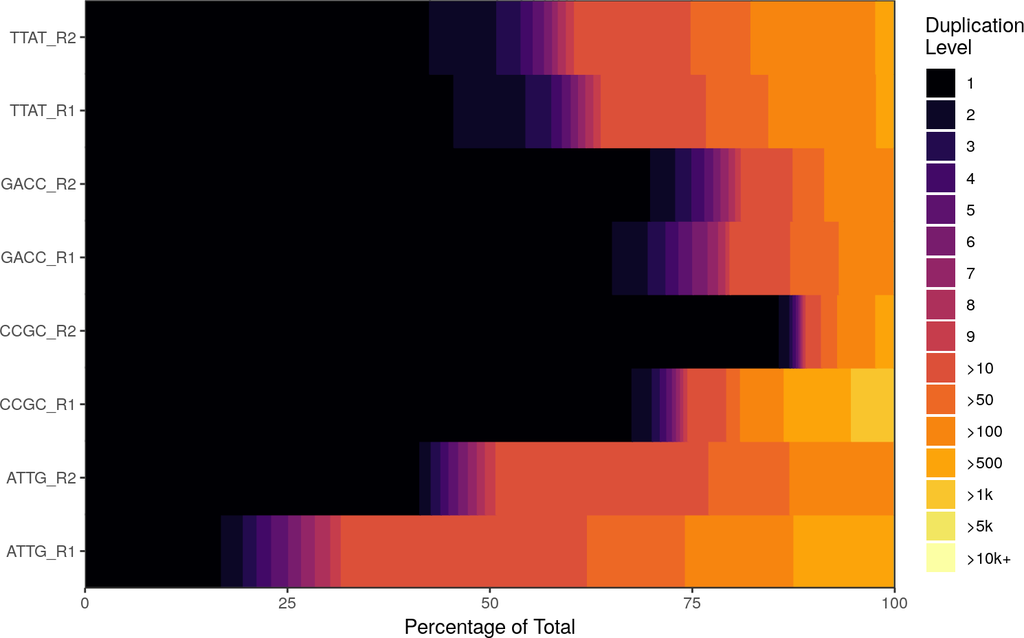

```r
plotDuplicationLevels(fdl)
```

### 3.3.9 plotAdapterContent()

Total Adapter Content is able to be plotted for complete set of files

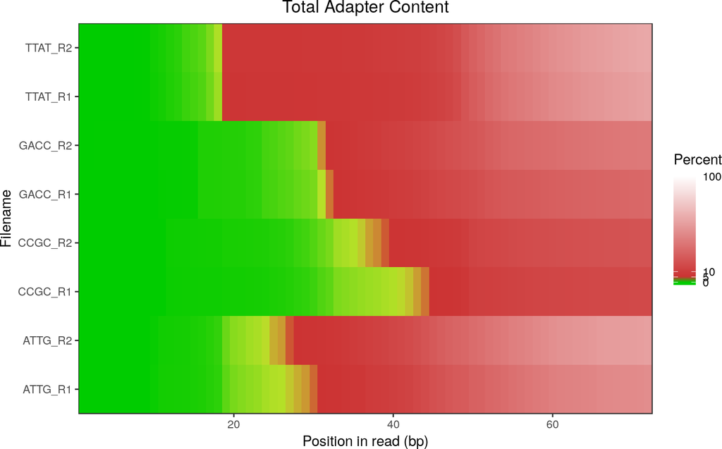

```r
plotAdapterContent(fdl)
```

Adapter content by individual adapter type is available for each individual file, as identified by FastQC.

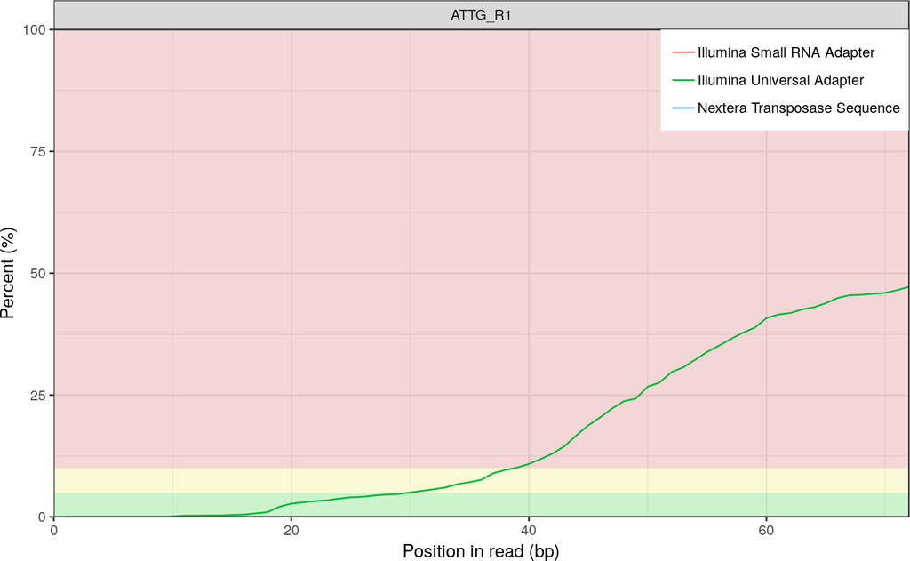

```r
plotAdapterContent(fdl[[1]])
```

### 3.3.10 plotKmers()

Althought not highly informative, particularly considering the binning across positions by FastQC, the totals of identified Kmers are plotted for a set of files.

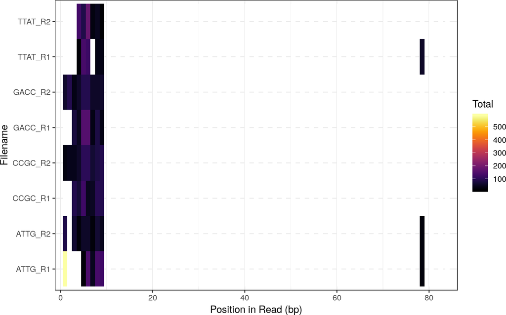

```r
plotKmers(fdl)
```

The top 6 Kmers, as conventionally displayed by FastQC can be simply obtained, however Kmers which overlap at indiviual positions may not be visible.

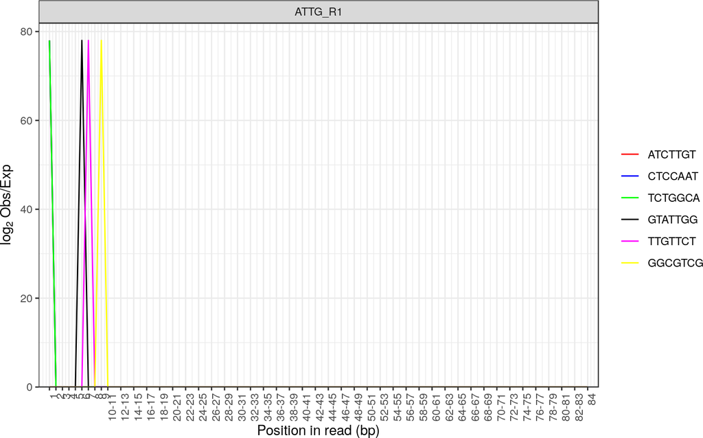

```r
plotKmers(fdl[[1]], axis.text.x = element_text(angle = 90))
```

## 3.4 GC content

### 3.4.1 The class TheoreticalGC

A selection of Theoretical GC content is supplied with the package in the object `gcTheoretical`, which has been defined with the additional `S4` class `TheoreticalGC`. GC content was calculated using scripts obtained from https://github.com/mikelove/fastqcTheoreticalGC. Available genomes and transcriptomes can be obtained using the functions `genomes()` and `transcriptomes()`

```r
transcriptomes(gcTheoretical)
genomes(gcTheoretical)
```

### 3.4.2 plotGcContent()

This function offers numerous possibilities, and is able to be presented as the difference from a theoretical GC content. By default, the difference is shown from the `Hsapiens` *genome*

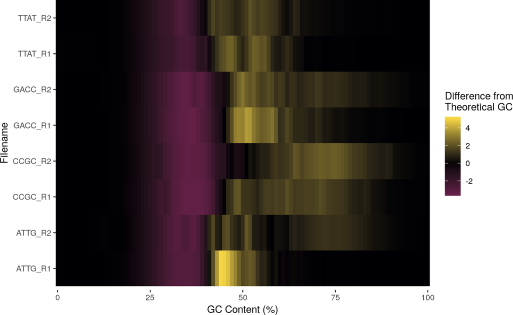

```r
plotGcContent(fdl)
```

This can be changed to the transcriptome by setting `theoreticalType = "Transcriptome"`. Alternative species can be also be selected from those made available

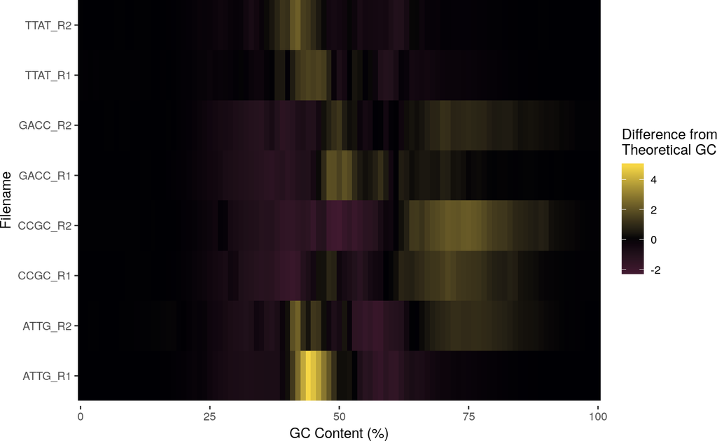

```r
plotGcContent(fdl, theoreticalType = "Transcriptome", species = "Mmusculus")
```

Customized theoretical GC content can be generated using input DNA sequences from a fasta file

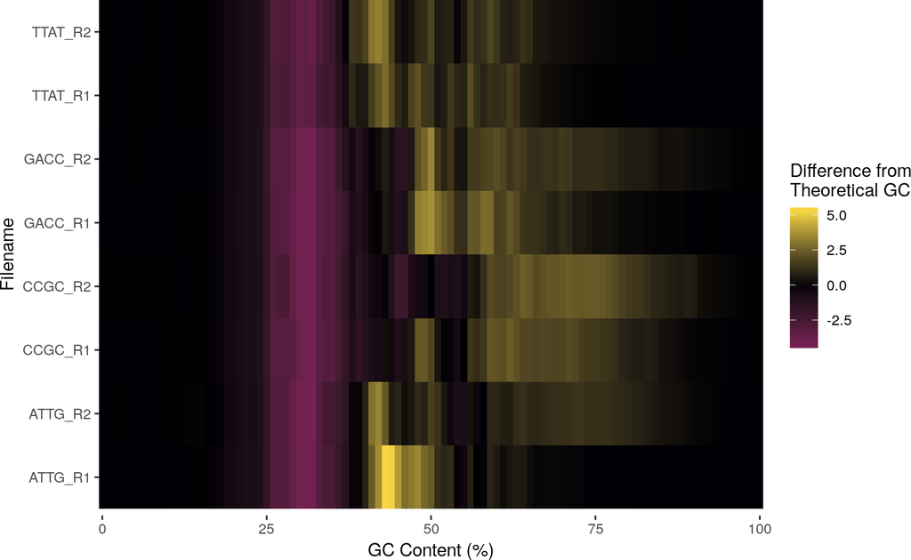

```r
faFile <- system.file("extdata", "Athaliana.TAIR10.tRNA.fasta", package="ngsReports")
plotGcContent(fdl, Fastafile = faFile)
```

Line plots can also be produced.

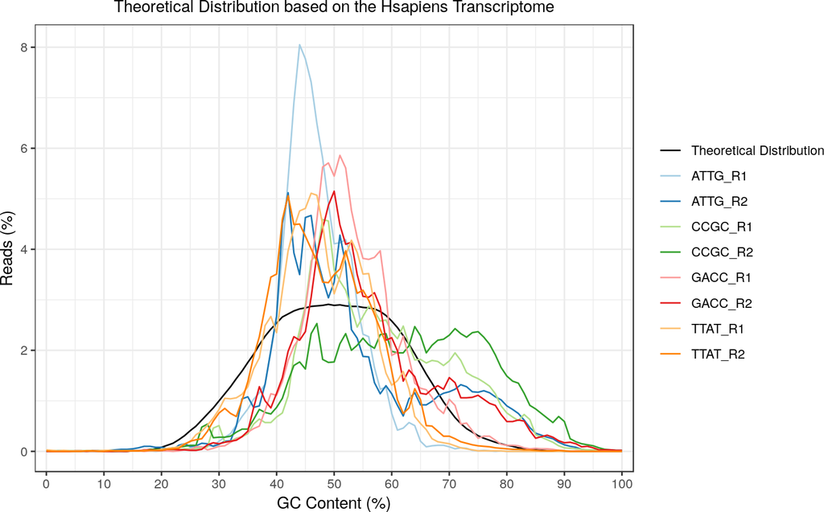

```r
plotGcContent(fdl, plotType = "line",  theoreticalType = "Transcriptome")
```

## 3.5 Overrepresented Sequences

Instead of identifying common sequences across a set of libraries, overrepresented sequenes are summarised by their possible source as defined by FastQC.

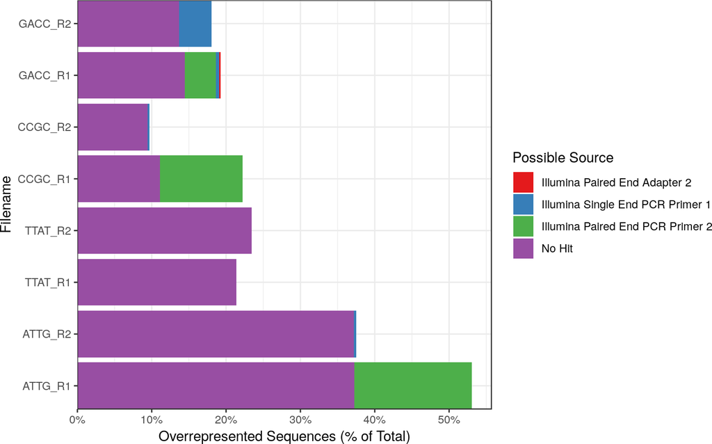

```r
plotOverrepresentedSummary(fdl)
```

The top `n`can be plotted for an individual file, again broken down by their possible source, and coloured based on their `WARN/FAIL` status

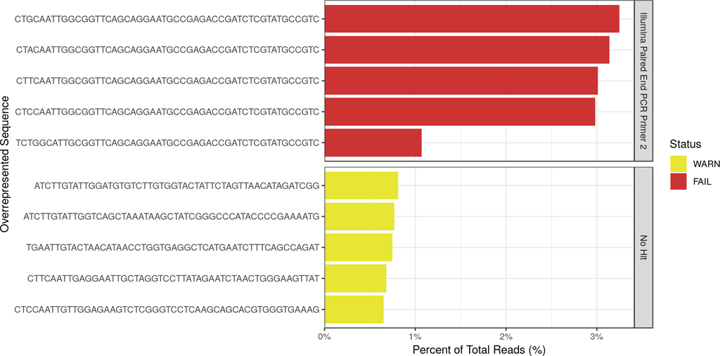

```r
plotOverrepresentedSummary(fdl[[1]])
```

In addition to the above, overrepresented sequences can be exported as a FASTA file for easy submission to `blast`.

```r
exportOverrepresented(fdl, n = 10)
```